# Comparison of different methods for calculationg weights in epiregulon with the use of the simulated data

Tomasz Włodarczyk 2023-07-04

- Introduction
- Highlights
- GRN preparation
- Distribution of the library sizes
- Comparison of weight methods based on the true counts (normalized)
  - Fixed cutoff
  - Moving cutoff
- Comparison of weight methods based on the observed counts (normalized)
  - Fixed cutoff
  - Moving cutoff
- Comparison of weight methods based on the observed counts (normalized and log transformed)
  - Fixed cutoff
  - Moving cutoff
- Effect of the number of target genes
- Effect of the network pruning
  - Pruning unconataminated regulon
    - Fixed cutoffs for pruning
    - Moving cutoffs for pruning
  - Contaminating regulon with 50% of false connections
    - Fixed cutoffs for pruning
    - Moving cutoffs for pruning
  - Contaminating regulon with 65% of false connections
    - Fixed cutoffs for pruning
    - Moving cutoffs for pruning
  - Contaminating regulon with 80% of false connections
    - Fixed cutoffs for pruning
    - Moving cutoffs for pruning
  - Removing 50% of true connections and contaminating regulon with 80% of false connections
    - Fixed cutoffs for pruning
    - Moving cutoffs for pruning
  - Removing 90% of true connections and contaminating regulon with 70% of false connections
    - Fixed cutoffs for pruning
    - Moving cutoffs for pruning
- Manipulating data sparsity
  - Sparsity lesser than default
    - Pruning unconataminated regulon
    - Contaminating regulon with 50% of false connections
    - Contaminating regulon with 65% of false connections
    - Contaminating regulon with 80% of false connections
    - Removing 50% of true connections and contaminating regulon with 80% of false connections
  - Sparsity greater than default
    - Pruning unconataminated regulon
    - Contaminating regulon with 50% of false connections
    - Contaminating regulon with 65% of false connections
    - Contaminating regulon with 80% of false connections
    - Removing 50% of true connections and contaminating regulon with 80% of false connections

```r
knitr::opts_chunk$set(
    echo = TRUE,
    message = FALSE,
    warning = FALSE
)
```

# Introduction

This notebook compares across all options for weight computation which are available in the epiregulon package. As a ground truth the data simulated by scMultiSim package is used.

# Highlights

- GRN is composed of 5000 target genes and 500 transcription factors
- 9 cell clusters
- normalization of the count data
- using moving cutoffs in the workflows with regulon pruning

# GRN preparation

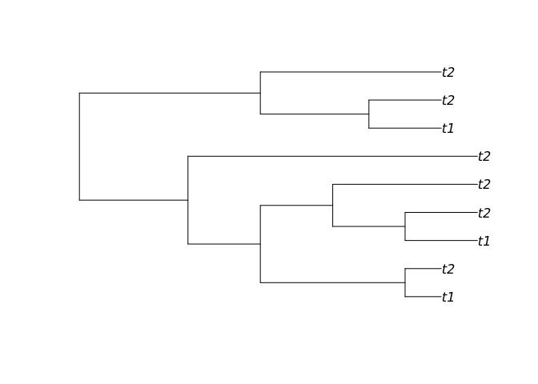

```r
set.seed(10101)
# number of target genes
n_target <- 5e3
# number of transcription factors
n_tf <- 500
# target numbers
n_targets <- rep(0, n_tf)
# minimum number of target genes per transcription factor should be 3
while(any(n_targets < 3))
    n_targets[n_targets < 3] <- rpois(sum(n_targets < 3), exp(runif(sum(n_targets < 3))*5))
n_targets[n_targets > n_target] = n_target
# set number of transcription factors per target gene
n_tfs_per_target <- sample(1:n_target, sum(n_targets)-n_target, replace  =TRUE)
# ensure at least one transcription factor per target gene
n_tfs_per_target <- c(n_tfs_per_target, 1:n_target)
n_tfs_per_target <- table(n_tfs_per_target)
reg_matrix <- matrix(0, ncol = n_tf, nrow = n_target, dimnames = list(1:n_target, (n_target+1):(n_target+n_tf)))
connected_targets <- c()
for (i in 1:ncol(reg_matrix)){
    # account for possible repeated target genes at the last step by using min function
    tgs <- sample(setdiff(1:n_target, connected_targets), min(n_targets[i], length(setdiff(1:n_target, connected_targets))))
    reg_matrix[tgs,i] <- 1
    # find exhausted targets
    connected_targets <- which(rowSums(reg_matrix)==n_tfs_per_target)
}

GRN <- reshape2::melt(reg_matrix)
GRN <- GRN[GRN[,3]==1, 1:2]
colnames(GRN) <- c("regulated.gene", "regulator.gene")
GRN$regulator.effect <- runif(nrow(GRN), min=1, max =5)

# prepare phylogenetic tree
library(ape)
phyla <- fork.tree <- stree(2)
phyla <- bind.tree(phyla, fork.tree, 1)
phyla <- bind.tree(phyla, phyla, 1)
phyla <- bind.tree(phyla, phyla, 1)
phyla <- compute.brlen(phyla, c(3, 2, 4, 1, 1, 2, 2, 2, 2, 4, 8, 5, 3, 2, 2, 5))
plot(phyla)
```

```r
# prepare simulation options
options_ = list(
    rand.seed = 0,
    GRN = GRN,
    num.cells = 5000, # number of cells
    num.cifs = 500,
    tree = phyla, # tree with 9 clusters
    intrinsic.noise = 0.9,
    giv.prob = 0.05,
    augmented.transcr = NULL, # custom parameter
    atac.effect = 0.5, # effect of regulatory element availability on k_on parameter
    diff.cif.fraction = 0.8, # fraction of CIFs related to the cell development
    discrete.cif = TRUE, # use discrete mode
    discrete.min.pop.size = 300)
```

```r
library(scMultiSim)
sim_res <- sim_true_counts(options_)

# add noise to gene expression and ATAC-seq data
set.seed(11000)
add_expr_noise(sim_res)
# pointers to objects starting with . will disappear during conversion from environment to list
.grn <- sim_res$.grn
sim_res <- as.list(sim_res)
sim_res$.grn <- .grn
dimnames(sim_res$counts_obs) <- dimnames(sim_res$counts)
saveRDS(sim_res, "/gstore/scratch/u/wlodarct/sim_res.rds")
```

```r
#Sys.setenv("R_MAX_VSIZE" = 30 * 2^30)
sim_res <- readRDS("/gstore/scratch/u/wlodarct/sim_res.rds")
```

```r
library(epiregulon.benchmark)
library(scMultiSim)
tfs <- NULL
counts_removal_old <- NULL
tfs <- unique(options_$GRN[,2])
# get gene expression data after removal of each transcription factor (one by one)
# analysed using 900Gb of RAM
# set in .Renviron R_MAX_VSIZE = "800Gb"
counts_removal <- removeTF(sim_res, BPPARAM = BiocParallel::MulticoreParam(),
                                  batch_size = 20, sim_options = options_,
                           tfs = tfs)

# calculate the effect of transcription factor by subtracting the gene expression matrix after removal
# from the basic dataset and summing transcription change across all the target genes
true_ranks_matrix <- calculateTrueActivityRanks(basic_sim_res = sim_res,
                                                counts_removal = counts_removal,
                                                sim_options = options_)

transcription_difference_matrix <- calculateTrueActivityRanks(basic_sim_res = sim_res,
                                                    counts_removal = counts_removal,
                                                    sim_options = options_,
                                                    transcription_effect = TRUE)
```

# Distribution of the library sizes

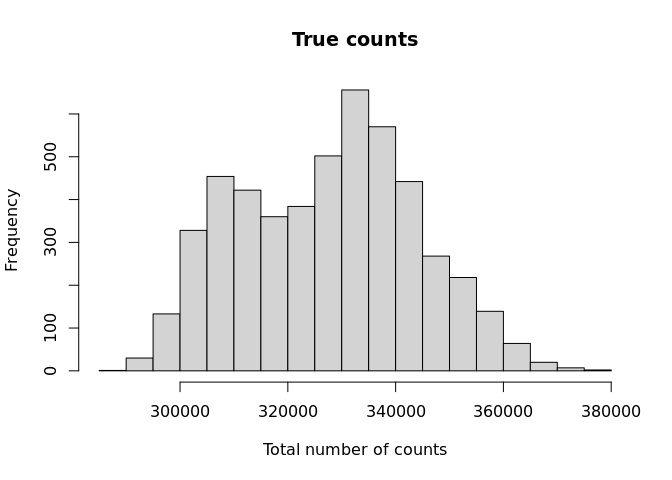

```r
hist(Matrix::colSums(sim_res$counts), main = "True counts", breaks = 30, xlab = "Total number of counts")
```

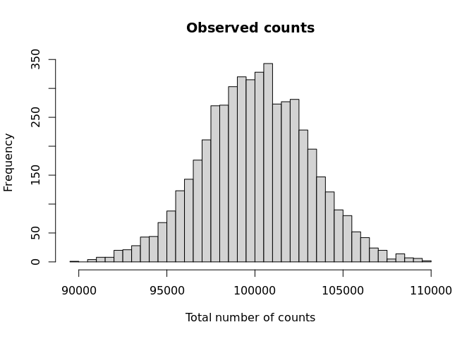

```r
hist(Matrix::colSums(sim_res$counts_obs), main = "Observed counts", breaks = 30, xlab = "Total number of counts")
```

# Comparison of weight methods based on the true counts (normalized)

## Fixed cutoff

```r
library(epiregulon)
library(epiregulon.benchmark)
#source("/gstore/project/epigen/epiregulon.benchmark/R/simulation.R")
input_objects <- processSimResults(sim_res)
clusters_list <- list("lmfit" = input_objects$geneExpMatrix$label,
                      "corr" = input_objects$geneExpMatrix$label,
                      "MI" = input_objects$geneExpMatrix$label)
# skip pruning since all connections are true
score_matrices  <- score_matrices_true_counts <-  getActivity(regulon = input_objects$regulon,
                              geneExpMatrix = input_objects$geneExpMatrix,
                              peakMatrix = input_objects$peakMatrix,
                              clusters_list = clusters_list,
                              exp_assay = "norm_counts",
                              peak_assay = "peak_obs")
```

```
##   |                                                                              |                                                                      |   0%  |                                                                              |                                                         …
##
##   |                                                                              |                                                                      |   0%  |                                                                              |                                                         …
##
##   |                                                                              |                                                                      |   0%  |                                                                              |                                                         …
##
##   |                                                                              |                                                                      |   0%  |                                                                              |                                                         …
```

```r
library(scMultiSim)
library(epiregulon.benchmark)
df <- data.frame()
cat("Number of transcription factors retained:\n")
```

```
## Number of transcription factors retained:
```

```r
for(i in seq_along(score_matrices)){
    cat(sprintf("%15s: %d (%.2f%%)\n", names(score_matrices)[i], nrow(score_matrices[[i]]), nrow(score_matrices[[i]])*100/nrow(true_ranks_matrix)))
    method_res <- assessActivityAccuracy(activities_obs = score_matrices[[i]],
                                         true_ranks_matrix = true_ranks_matrix)

    df <- rbind(df, data.frame(tf = names(method_res$interchange_number),
                               method = names(score_matrices)[i],
                               interchanges = method_res$interchange_number))
}
```

```
##        wilcoxon: 182 (36.40%)
##           logFC: 182 (36.40%)
##           lmfit: 376 (75.20%)
##            corr: 376 (75.20%)
##              MI: 376 (75.20%)
```

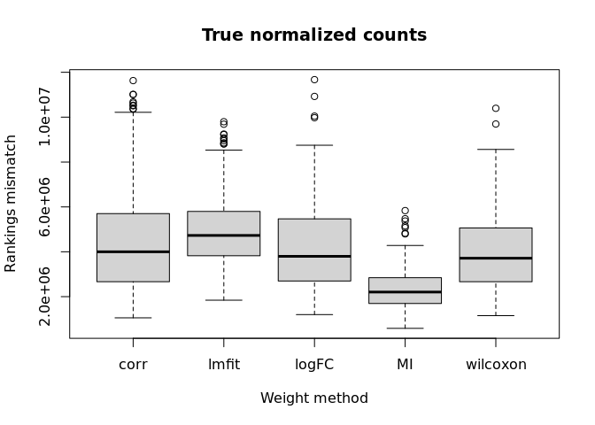

```r
boxplot(df$interchanges~df$method, xlab = "Weight method", ylab = "Rankings mismatch", main = "True normalized counts")
```

## Moving cutoff

```r
score_matrices  <- score_matrices_true_counts <-  getActivity(regulon = input_objects$regulon,
                              geneExpMatrix = input_objects$geneExpMatrix,
                              peakMatrix = input_objects$peakMatrix,
                              clusters_list = clusters_list,
                              exp_assay = "norm_counts",
                              peak_assay = "peak_obs",
                              peak_cutoff = NULL,
                              exp_cutoff = NULL)
```

```
##   |                                                                              |                                                                      |   0%  |                                                                              |                                                         …
##
##   |                                                                              |                                                                      |   0%  |                                                                              |                                                         …
##
##   |                                                                              |                                                                      |   0%  |                                                                              |                                                         …
##
##   |                                                                              |                                                                      |   0%  |                                                                              |                                                         …
```

```r
library(scMultiSim)
library(epiregulon.benchmark)
df <- data.frame()
cat("Number of transcription factors retained:\n")
```

```
## Number of transcription factors retained:
```

```r
for(i in seq_along(score_matrices)){
    cat(sprintf("%15s: %d (%.2f%%)\n", names(score_matrices)[i], nrow(score_matrices[[i]]), nrow(score_matrices[[i]])*100/nrow(true_ranks_matrix)))
    method_res <- assessActivityAccuracy(activities_obs = score_matrices[[i]],
                                         true_ranks_matrix = true_ranks_matrix)

    df <- rbind(df, data.frame(tf = names(method_res$interchange_number),
                               method = names(score_matrices)[i],
                               interchanges = method_res$interchange_number))
}
```

```
##        wilcoxon: 376 (75.20%)
##           logFC: 376 (75.20%)
##           lmfit: 376 (75.20%)
##            corr: 376 (75.20%)
##              MI: 376 (75.20%)
```

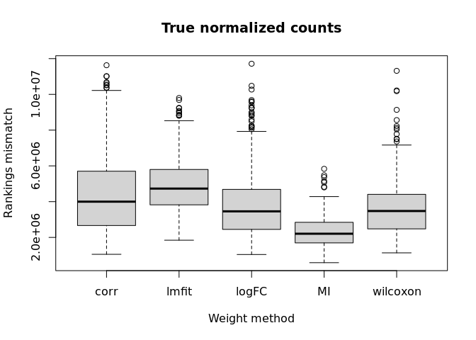

```r
boxplot(df$interchanges~df$method, xlab = "Weight method", ylab = "Rankings mismatch", main = "True normalized counts")
```

# Comparison of weight methods based on the observed counts (normalized)

## Fixed cutoff

```r
score_matrices <- getActivity(regulon = input_objects$regulon,
                              geneExpMatrix = input_objects$geneExpMatrix,
                              peakMatrix = input_objects$peakMatrix,
                              clusters_list = clusters_list,
                              exp_assay = "norm_counts_obs",
                              peak_assay = "peak_obs")
```

```
##   |                                                                              |                                                                      |   0%  |                                                                              |                                                         …
##
##   |                                                                              |                                                                      |   0%  |                                                                              |                                                         …
##
##   |                                                                              |                                                                      |   0%  |                                                                              |                                                         …
##
##   |                                                                              |                                                                      |   0%  |                                                                              |                                                         …
```

```r
df <- data.frame()
cat("Number of transcription factors retained:\n")
```

```
## Number of transcription factors retained:
```

```r
for(i in seq_along(score_matrices)){
    cat(sprintf("%15s: %d (%.2f%%)\n", names(score_matrices)[i], nrow(score_matrices[[i]]), nrow(score_matrices[[i]])*100/nrow(true_ranks_matrix)))
    method_res <- assessActivityAccuracy(activities_obs = score_matrices[[i]],
                                         true_ranks_matrix = true_ranks_matrix)

    df <- rbind(df, data.frame(tf = names(method_res$interchange_number), method = names(score_matrices)[i],
                               interchanges = method_res$interchange_number))
}
```

```
##        wilcoxon: 371 (74.20%)
##           logFC: 371 (74.20%)
##           lmfit: 375 (75.00%)
##            corr: 375 (75.00%)
##              MI: 375 (75.00%)
```

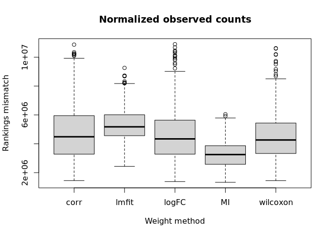

```r
boxplot(df$interchanges~df$method, xlab = "Weight method", ylab = "Rankings mismatch",  main = "Normalized observed counts")
```

## Moving cutoff

```r
score_matrices <- getActivity(regulon = input_objects$regulon,
                              geneExpMatrix = input_objects$geneExpMatrix,
                              peakMatrix = input_objects$peakMatrix,
                              clusters_list = clusters_list,
                              exp_assay = "norm_counts_obs",
                              peak_assay = "peak_obs",
                              peak_cutoff = NULL,
                              exp_cutoff = NULL)
```

```
##   |                                                                              |                                                                      |   0%  |                                                                              |                                                         …
##
##   |                                                                              |                                                                      |   0%  |                                                                              |                                                         …
##
##   |                                                                              |                                                                      |   0%  |                                                                              |                                                         …
##
##   |                                                                              |                                                                      |   0%  |                                                                              |                                                         …
```

```r
df <- data.frame()
cat("Number of transcription factors retained:\n")
```

```
## Number of transcription factors retained:
```

```r
for(i in seq_along(score_matrices)){
    cat(sprintf("%15s: %d (%.2f%%)\n", names(score_matrices)[i], nrow(score_matrices[[i]]), nrow(score_matrices[[i]])*100/nrow(true_ranks_matrix)))
    method_res <- assessActivityAccuracy(activities_obs = score_matrices[[i]],
                                         true_ranks_matrix = true_ranks_matrix)

    df <- rbind(df, data.frame(tf = names(method_res$interchange_number), method = names(score_matrices)[i],
                               interchanges = method_res$interchange_number))
}
```

```
##        wilcoxon: 375 (75.00%)
##           logFC: 375 (75.00%)
##           lmfit: 375 (75.00%)
##            corr: 375 (75.00%)
##              MI: 375 (75.00%)
```

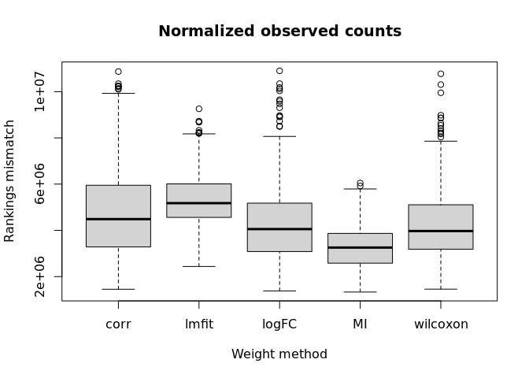

```r
boxplot(df$interchanges~df$method, xlab = "Weight method", ylab = "Rankings mismatch",  main = "Normalized observed counts")
```

# Comparison of weight methods based on the observed counts (normalized and log transformed)

## Fixed cutoff

```
##   |                                                                              |                                                                      |   0%  |                                                                              |                                                         …
##
##   |                                                                              |                                                                      |   0%  |                                                                              |                                                         …
##
##   |                                                                              |                                                                      |   0%  |                                                                              |                                                         …
##
##   |                                                                              |                                                                      |   0%  |                                                                              |                                                         …

## Number of transcription factors retained:

##        wilcoxon: 371 (74.20%)
##           logFC: 371 (74.20%)
##           lmfit: 375 (75.00%)
##            corr: 375 (75.00%)
##              MI: 375 (75.00%)
```

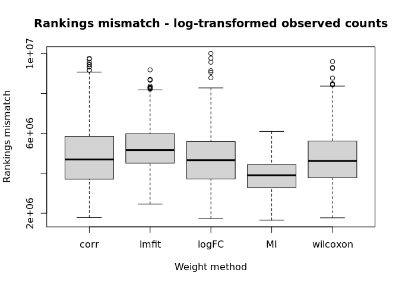

## Moving cutoff

```
##   |                                                                              |                                                                      |   0%  |                                                                              |                                                         …
##
##   |                                                                              |                                                                      |   0%  |                                                                              |                                                         …
##
##   |                                                                              |                                                                      |   0%  |                                                                              |                                                         …
##
##   |                                                                              |                                                                      |   0%  |                                                                              |                                                         …

## Number of transcription factors retained:

##        wilcoxon: 375 (75.00%)
##           logFC: 375 (75.00%)
##           lmfit: 375 (75.00%)
##            corr: 375 (75.00%)
##              MI: 375 (75.00%)
```

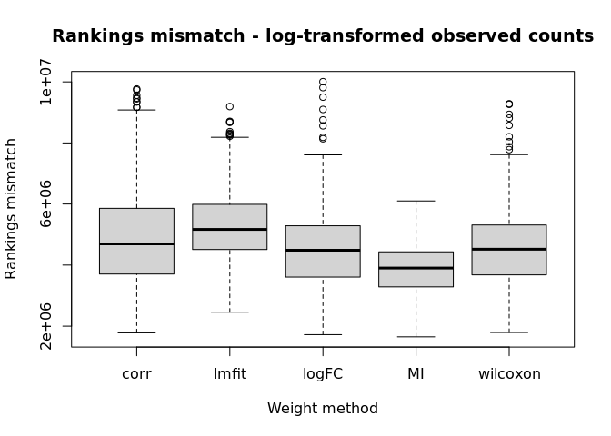

# Effect of the number of target genes

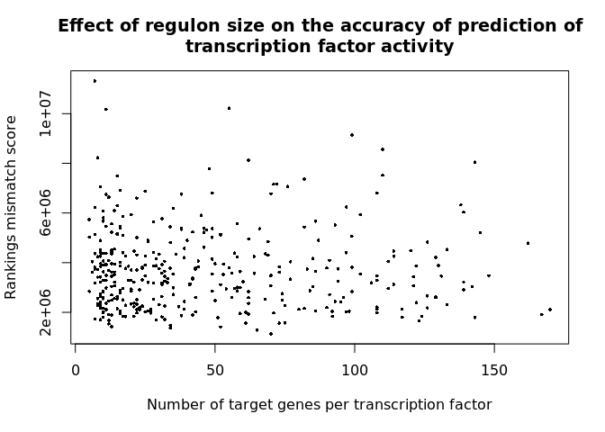

```r
# calculate ranking mismatch score for true counts analysed using wilcoxon method in addWeights
ranking_accuracy_wilcoxon <- assessActivityAccuracy(activities_obs = score_matrices_true_counts$wilcoxon, true_ranks_matrix = true_ranks_matrix)

# determine number of target genes per tf
target_number <- split(options_$GRN,options_$GRN$regulator.gene) |>
    lapply(nrow) |>
    {function(x) unlist(x)}()
df <- data.frame(interchange_number = ranking_accuracy_wilcoxon$interchange_number,
                 target_number = target_number[names(ranking_accuracy_wilcoxon$interchange_number)])

plot(df$interchange_number~df$target_number, main = "Effect of regulon size on the accuracy of prediction of\ntranscription factor activity", xlab = "Number of target genes per transcription factor", ylab = "Rankings mismatch score", pch = 16, cex = 0.5)
```

# Effect of the network pruning

Now let’s check the methods’ performance by adding false connections and playing around with different cutoff values for the output from `pruneRegulon` function. By default we use moving cutoffs for binarization of peak and gene expression data. Moreover, only normalized true counts and true peak data are analysed. We start with pruning the true regulon (without adding any false connections).

## Pruning unconataminated regulon

### Fixed cutoffs for pruning

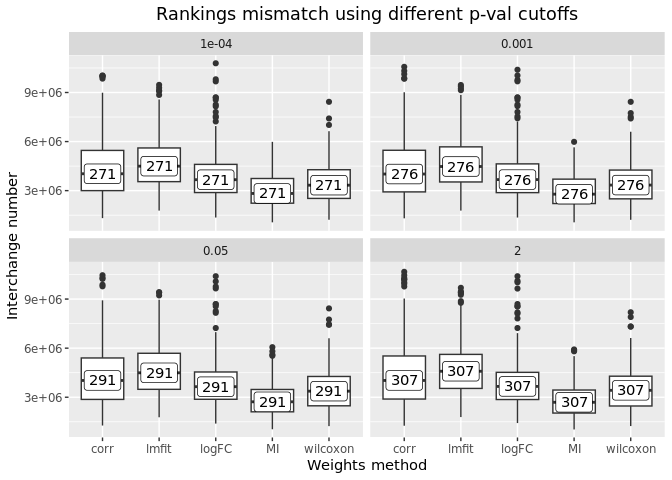

```r
accuracyComparisonPruning(input_objects$regulon, input_objects, true_ranks_matrix) |>
    ggplot(aes(x = method, y = interchanges, label = n_tf))+
    geom_boxplot()+
    stat_summary(fun = median, geom = "label")+
    facet_wrap(~pval_cutoff, ncol = 2)+
    xlab("Weights method")+
    ylab("Interchange number")+
    ggtitle("Rankings mismatch using different p-val cutoffs")+
    theme(plot.title = element_text(hjust = 0.5))
```

### Moving cutoffs for pruning

#### True counts

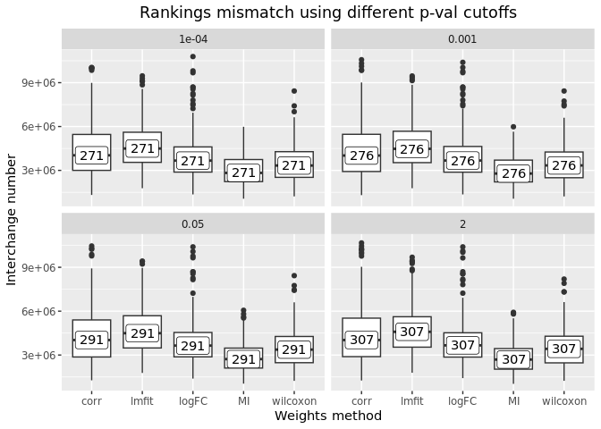

```r
accuracyComparisonPruning(input_objects$regulon, input_objects, true_ranks_matrix,
                          exp_cutoff = NULL,
                          peak_cutoff = NULL) |>
    ggplot(aes(x = method, y = interchanges, label = n_tf))+
    geom_boxplot()+
    stat_summary(fun = median, geom = "label")+
    facet_wrap(~pval_cutoff, ncol = 2)+
    xlab("Weights method")+
    ylab("Interchange number")+
    ggtitle("Rankings mismatch using different p-val cutoffs")+
    theme(plot.title = element_text(hjust = 0.5))
```

#### Observed counts

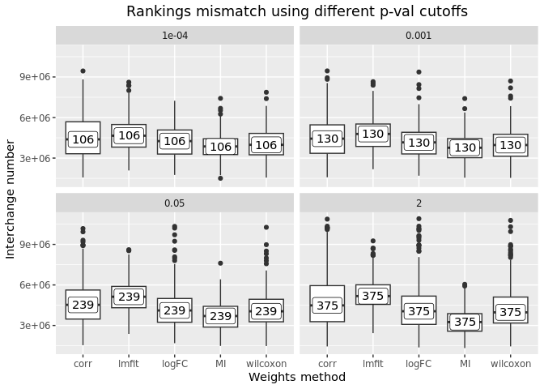

```r
accuracyComparisonPruning(input_objects$regulon, input_objects, true_ranks_matrix,
                          exp_cutoff = NULL,
                          peak_cutoff = NULL,
                          exp_assay = "norm_counts_obs",
                          peak_assay = "peak_obs") |>
    ggplot(aes(x = method, y = interchanges, label = n_tf))+
    geom_boxplot()+
    stat_summary(fun = median, geom = "label")+
    facet_wrap(~pval_cutoff, ncol = 2)+
    xlab("Weights method")+
    ylab("Interchange number")+
    ggtitle("Rankings mismatch using different p-val cutoffs")+
    theme(plot.title = element_text(hjust = 0.5))
```

## Contaminating regulon with 50% of false connections

```r
regulon.mixed <- addFalseConnections(input_objects$regulon)
```

### Fixed cutoffs for pruning

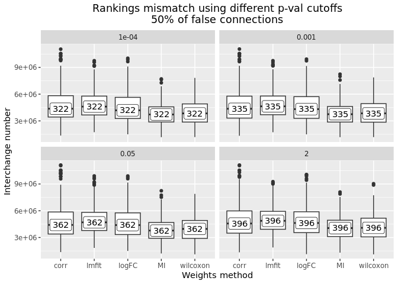

```r
accuracyComparisonPruning(regulon.mixed, input_objects, true_ranks_matrix) |>
    ggplot(aes(x = method, y = interchanges, label = n_tf))+
    geom_boxplot()+
    stat_summary(fun = median, geom = "label")+
    facet_wrap(~pval_cutoff, ncol = 2)+
    xlab("Weights method")+
    ylab("Interchange number")+
    ggtitle("Rankings mismatch using different p-val cutoffs\n50% of false connections")+
    theme(plot.title = element_text(hjust = 0.5))
```

### Moving cutoffs for pruning

#### True counts

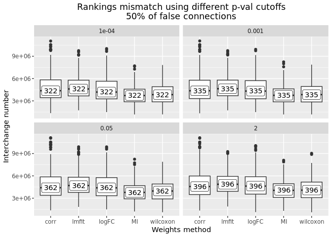

```r
accuracyComparisonPruning(regulon.mixed, input_objects, true_ranks_matrix,
                          exp_cutoff = NULL,
                          peak_cutoff = NULL) |>
    ggplot(aes(x = method, y = interchanges, label = n_tf))+
    geom_boxplot()+
    stat_summary(fun = median, geom = "label")+
    facet_wrap(~pval_cutoff, ncol = 2)+
    xlab("Weights method")+
    ylab("Interchange number")+
    ggtitle("Rankings mismatch using different p-val cutoffs\n50% of false connections")+
    theme(plot.title = element_text(hjust = 0.5))
```

#### Observed counts

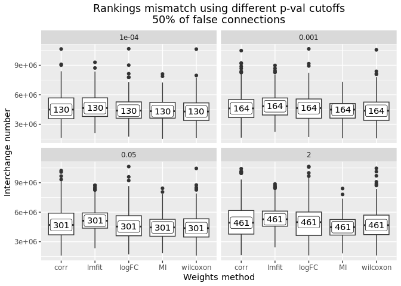

```r
accuracyComparisonPruning(regulon.mixed, input_objects, true_ranks_matrix,
                          exp_cutoff = NULL,
                          peak_cutoff = NULL,
                          exp_assay = "norm_counts_obs",
                          peak_assay = "peak_obs") |>
    ggplot(aes(x = method, y = interchanges, label = n_tf))+
    geom_boxplot()+
    stat_summary(fun = median, geom = "label")+
    facet_wrap(~pval_cutoff, ncol = 2)+
    xlab("Weights method")+
    ylab("Interchange number")+
    ggtitle("Rankings mismatch using different p-val cutoffs\n50% of false connections")+
    theme(plot.title = element_text(hjust = 0.5))
```

## Contaminating regulon with 65% of false connections

```r
regulon.mixed <- addFalseConnections(input_objects$regulon,
                                     fraction_false = 0.65)
```

### Fixed cutoffs for pruning

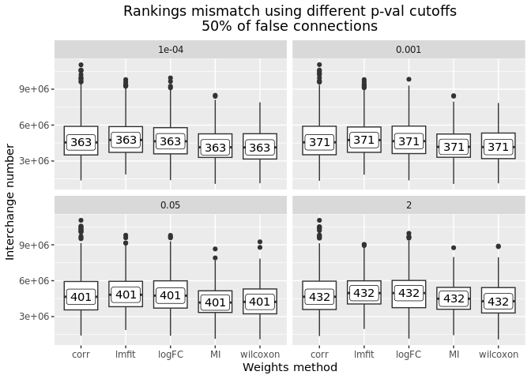

```r
accuracyComparisonPruning(regulon.mixed, input_objects, true_ranks_matrix) |>
    ggplot(aes(x = method, y = interchanges, label = n_tf))+
    geom_boxplot()+
    stat_summary(fun = median, geom = "label")+
    facet_wrap(~pval_cutoff, ncol = 2)+
    xlab("Weights method")+
    ylab("Interchange number")+
    ggtitle("Rankings mismatch using different p-val cutoffs\n50% of false connections")+
    theme(plot.title = element_text(hjust = 0.5))
```

### Moving cutoffs for pruning

#### True counts

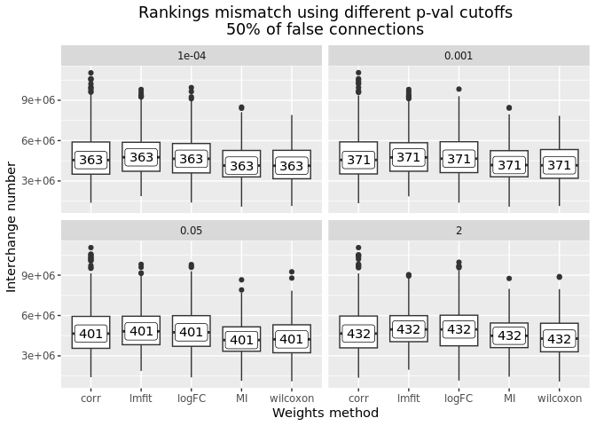

```r
accuracyComparisonPruning(regulon.mixed, input_objects, true_ranks_matrix,
                          exp_cutoff = NULL,
                          peak_cutoff = NULL) |>
    ggplot(aes(x = method, y = interchanges, label = n_tf))+
    geom_boxplot()+
    stat_summary(fun = median, geom = "label")+
    facet_wrap(~pval_cutoff, ncol = 2)+
    xlab("Weights method")+
    ylab("Interchange number")+
    ggtitle("Rankings mismatch using different p-val cutoffs\n50% of false connections")+
    theme(plot.title = element_text(hjust = 0.5))
```

#### Observed counts

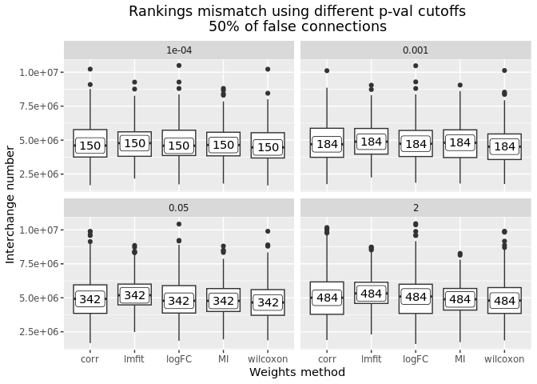

```r
accuracyComparisonPruning(regulon.mixed, input_objects, true_ranks_matrix,
                          exp_cutoff = NULL,
                          peak_cutoff = NULL,
                          exp_assay = "norm_counts_obs",
                          peak_assay = "peak_obs") |>
    ggplot(aes(x = method, y = interchanges, label = n_tf))+
    geom_boxplot()+
    stat_summary(fun = median, geom = "label")+
    facet_wrap(~pval_cutoff, ncol = 2)+
    xlab("Weights method")+
    ylab("Interchange number")+
    ggtitle("Rankings mismatch using different p-val cutoffs\n50% of false connections")+
    theme(plot.title = element_text(hjust = 0.5))
```

## Contaminating regulon with 80% of false connections

```r
regulon.mixed <- addFalseConnections(input_objects$regulon,
                                     fraction_false = 0.8)
```

### Fixed cutoffs for pruning

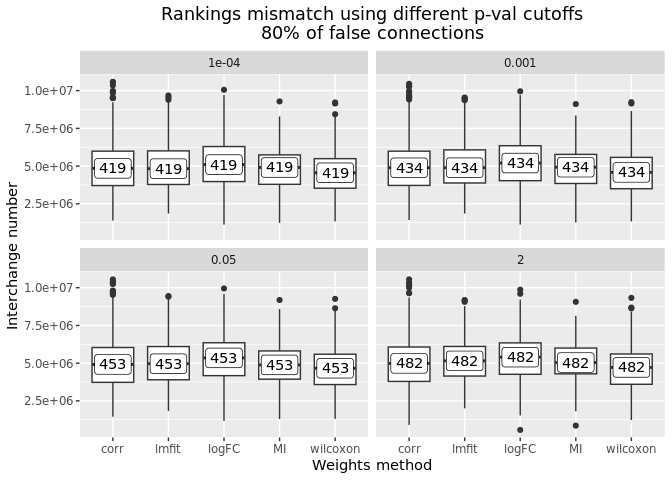

```r
accuracyComparisonPruning(regulon.mixed, input_objects, true_ranks_matrix) |>
    ggplot(aes(x = method, y = interchanges, label = n_tf))+
    geom_boxplot()+
    stat_summary(fun = median, geom = "label")+
    facet_wrap(~pval_cutoff, ncol = 2)+
    xlab("Weights method")+
    ylab("Interchange number")+
    ggtitle("Rankings mismatch using different p-val cutoffs\n80% of false connections")+
    theme(plot.title = element_text(hjust = 0.5))
```

### Moving cutoffs for pruning

#### True counts

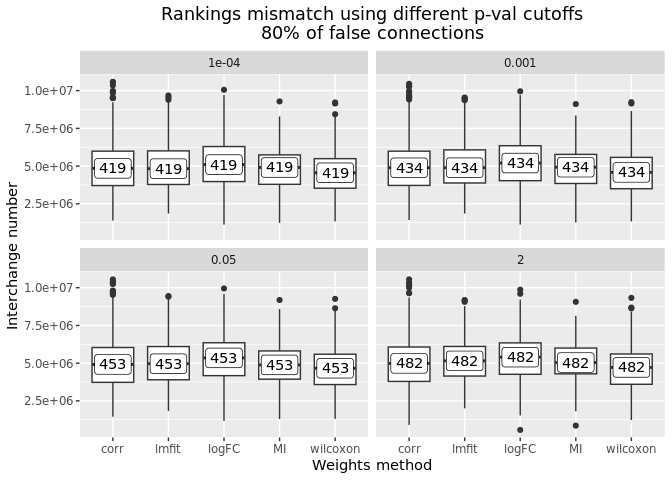

```r
accuracyComparisonPruning(regulon.mixed, input_objects, true_ranks_matrix,
                          exp_cutoff = NULL,
                          peak_cutoff = NULL) |>
    ggplot(aes(x = method, y = interchanges, label = n_tf))+
    geom_boxplot()+
    stat_summary(fun = median, geom = "label")+
    facet_wrap(~pval_cutoff, ncol = 2)+
    xlab("Weights method")+
    ylab("Interchange number")+
    ggtitle("Rankings mismatch using different p-val cutoffs\n80% of false connections")+
    theme(plot.title = element_text(hjust = 0.5))
```

#### Observed counts

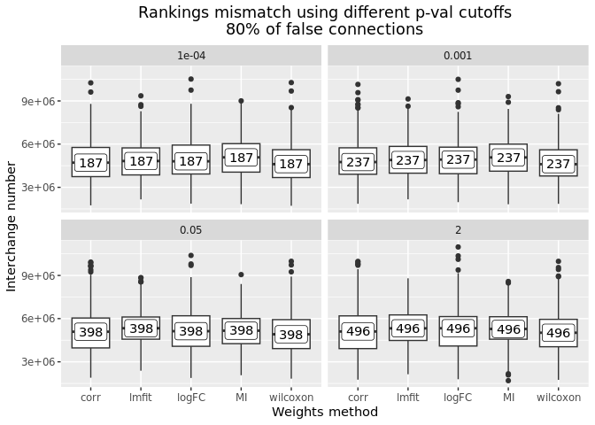

```r
accuracyComparisonPruning(regulon.mixed, input_objects, true_ranks_matrix,
                          exp_cutoff = NULL,
                          peak_cutoff = NULL,
                          exp_assay = "norm_counts_obs",
                          peak_assay = "peak_obs") |>
    ggplot(aes(x = method, y = interchanges, label = n_tf))+
    geom_boxplot()+
    stat_summary(fun = median, geom = "label")+
    facet_wrap(~pval_cutoff, ncol = 2)+
    xlab("Weights method")+
    ylab("Interchange number")+
    ggtitle("Rankings mismatch using different p-val cutoffs\n80% of false connections")+
    theme(plot.title = element_text(hjust = 0.5))
```

## Removing 50% of true connections and contaminating regulon with 80% of false connections

```r
set.seed(1110)
# remove part of the true connections
keep_ind <- sample(1:nrow(input_objects$regulon), round(nrow(input_objects$regulon)/2))
regulon.mixed <- addFalseConnections(input_objects$regulon[keep_ind,], fraction_false = 0.8)
```

### Fixed cutoffs for pruning

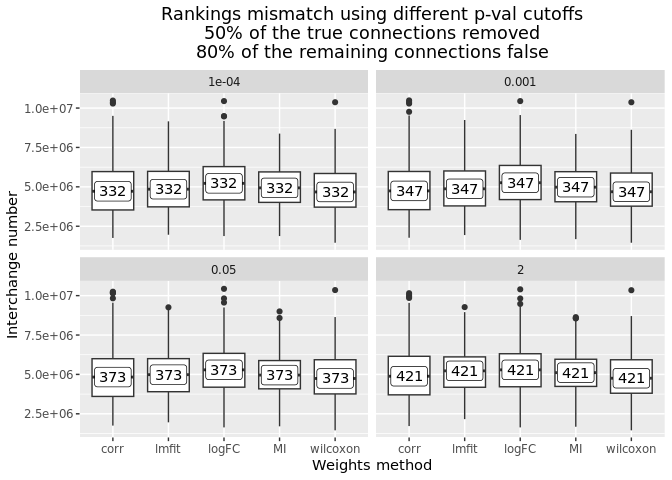

```r
accuracyComparisonPruning(regulon.mixed, input_objects, true_ranks_matrix) |>
    ggplot(aes(x = method, y = interchanges, label = n_tf))+
    geom_boxplot()+
    stat_summary(fun = median, geom = "label")+
    facet_wrap(~pval_cutoff, ncol = 2)+
    xlab("Weights method")+
    ylab("Interchange number")+
    ggtitle("Rankings mismatch using different p-val cutoffs\n50% of the true connections removed\n80% of the remaining connections false")+
    theme(plot.title = element_text(hjust = 0.5))
```

### Moving cutoffs for pruning

#### True counts

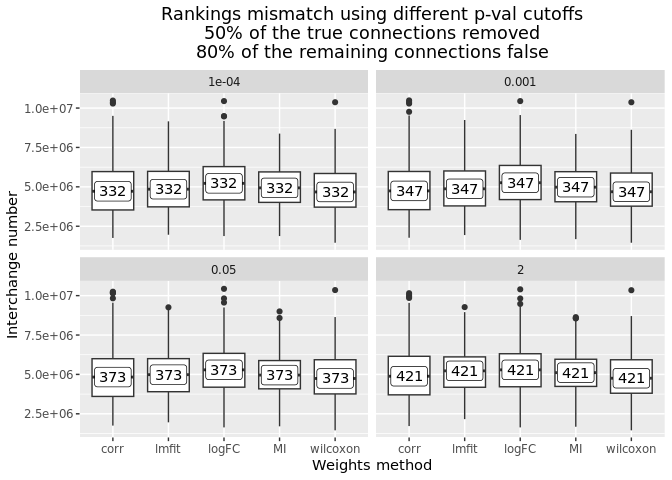

```r
accuracyComparisonPruning(regulon.mixed, input_objects, true_ranks_matrix,
                          exp_cutoff = NULL,
                          peak_cutoff = NULL) |>
    ggplot(aes(x = method, y = interchanges, label = n_tf))+
    geom_boxplot()+
    stat_summary(fun = median, geom = "label")+
    facet_wrap(~pval_cutoff, ncol = 2)+
    xlab("Weights method")+
    ylab("Interchange number")+
    ggtitle("Rankings mismatch using different p-val cutoffs\n50% of the true connections removed\n80% of the remaining connections false")+
    theme(plot.title = element_text(hjust = 0.5))
```

#### Observed counts

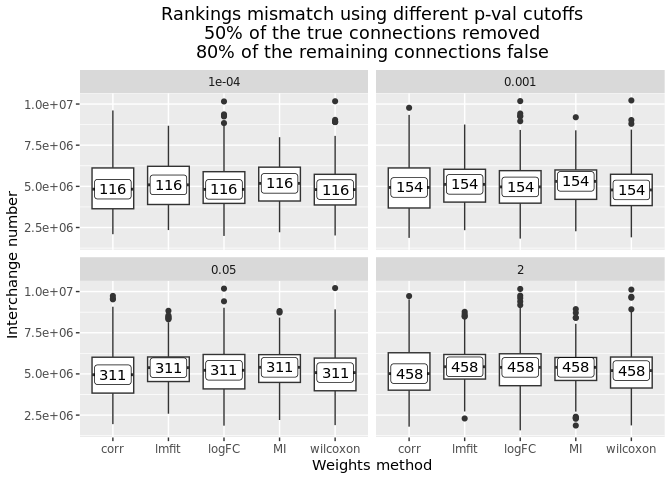

```r
accuracyComparisonPruning(regulon.mixed, input_objects, true_ranks_matrix,
                          exp_cutoff = NULL,
                          peak_cutoff = NULL,
                          exp_assay = "norm_counts_obs",
                          peak_assay = "peak_obs") |>
    ggplot(aes(x = method, y = interchanges, label = n_tf))+
    geom_boxplot()+
    stat_summary(fun = median, geom = "label")+
    facet_wrap(~pval_cutoff, ncol = 2)+
    xlab("Weights method")+
    ylab("Interchange number")+
    ggtitle("Rankings mismatch using different p-val cutoffs\n50% of the true connections removed\n80% of the remaining connections false")+
    theme(plot.title = element_text(hjust = 0.5))
```

## Removing 90% of true connections and contaminating regulon with 70% of false connections

```r
set.seed(1110)
# remove part of the true connections
keep_ind <- sample(1:nrow(input_objects$regulon), round(nrow(input_objects$regulon)*0.1))
regulon.mixed <- addFalseConnections(input_objects$regulon[keep_ind,], fraction_false = 0.7)
```

### Fixed cutoffs for pruning

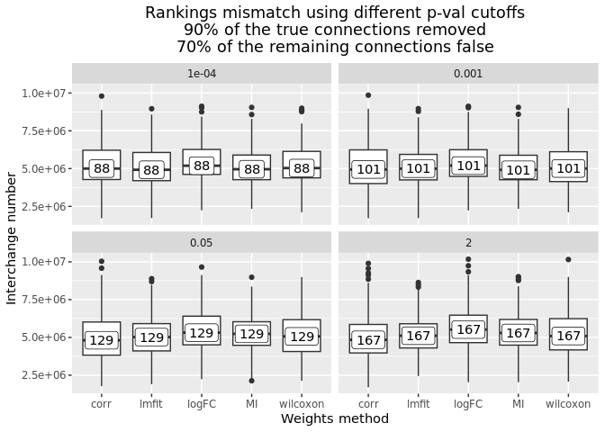

```r
accuracyComparisonPruning(regulon.mixed, input_objects, true_ranks_matrix) |>
    ggplot(aes(x = method, y = interchanges, label = n_tf))+
    geom_boxplot()+
    stat_summary(fun = median, geom = "label")+
    facet_wrap(~pval_cutoff, ncol = 2)+
    xlab("Weights method")+
    ylab("Interchange number")+
    ggtitle("Rankings mismatch using different p-val cutoffs\n90% of the true connections removed\n70% of the remaining connections false")+
    theme(plot.title = element_text(hjust = 0.5))
```

### Moving cutoffs for pruning

#### True counts

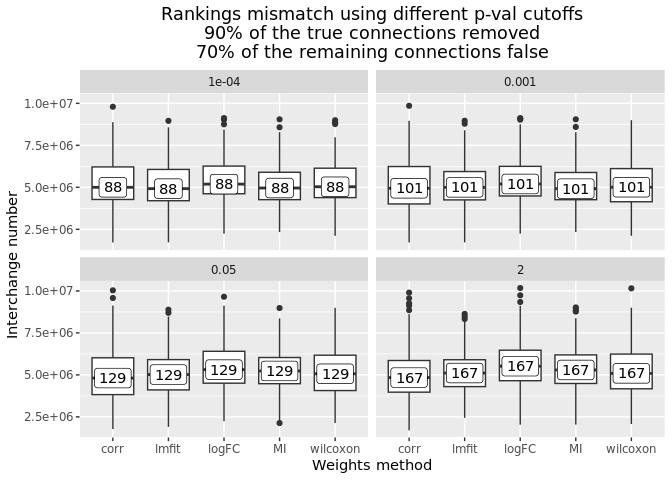

```r
accuracyComparisonPruning(regulon.mixed, input_objects, true_ranks_matrix,
                          exp_cutoff = NULL,
                          peak_cutoff = NULL) |>
    ggplot(aes(x = method, y = interchanges, label = n_tf))+
    geom_boxplot()+
    stat_summary(fun = median, geom = "label")+
    facet_wrap(~pval_cutoff, ncol = 2)+
    xlab("Weights method")+
    ylab("Interchange number")+
    ggtitle("Rankings mismatch using different p-val cutoffs\n90% of the true connections removed\n70% of the remaining connections false")+
    theme(plot.title = element_text(hjust = 0.5))
```

#### Observed counts

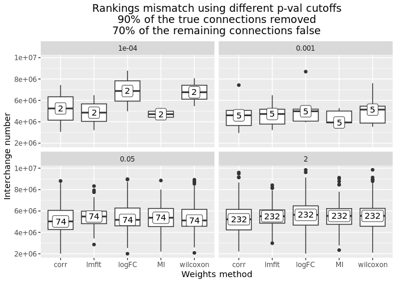

```r
accuracyComparisonPruning(regulon.mixed, input_objects, true_ranks_matrix,
                          exp_cutoff = NULL,
                          peak_cutoff = NULL,
                          exp_assay = "norm_counts_obs",
                          peak_assay = "peak_obs") |>
    ggplot(aes(x = method, y = interchanges, label = n_tf))+
    geom_boxplot()+
    stat_summary(fun = median, geom = "label")+
    facet_wrap(~pval_cutoff, ncol = 2)+
    xlab("Weights method")+
    ylab("Interchange number")+
    ggtitle("Rankings mismatch using different p-val cutoffs\n90% of the true connections removed\n70% of the remaining connections false")+
    theme(plot.title = element_text(hjust = 0.5))
```

# Manipulating data sparsity

We can modify parameters which generate technical noise in our data. We will set non-default values to the following parameters - `alpha_mean` which is the the mean of the normal distribution used to sample efficiency with transcripts are captured from the library - `alpha_sd` which is the standard deviation of the above distribution, i.e. determined how much cells differ from each other - `alpha_gene_meea` which is the mean of the normal distribution from which gene-specific capture effciency will be sampled - `alpha_gene_sd` which is the standard deviation for the above distribution - `depth_mean` which is the the mean of the normal distribution used to sample library sequencing depth - `depth_sd` which is the standard deviation for the above distribution - `observation_prob` which corresponds to the probability that ATACseq count will be included in the final dataset - `sd_frac` which controls for the size of the noise relative to the signal of ATACseq.

## Sparsity lesser than default

```r
set.seed(11000)
data("gene_len_pool", package = "scMultiSim")
gene_len <- sample(gene_len_pool, sim_res$num_genes, replace = FALSE)
true_counts <- floor(sim_res$counts)
meta_cell <- sim_res$cell_meta
sim_res$counts_obs <- True2ObservedCounts(true_counts = true_counts, meta_cell = meta_cell,
                                          protocol = "UMI", randseed = 0, alpha_mean = 0.5,
                                          alpha_sd = 0.001, alpha_gene_mean = 1, alpha_gene_sd = 0,
                                          gene_len = gene_len, depth_mean = 2e5, depth_sd = 1e3)$counts
```

```
## 50..100..150..200..250..300..350..400..450..500..550..600..650..700..750..800..850..900..950..1000..1050..1100..1150..1200..1250..1300..1350..1400..1450..1500..1550..1600..1650..1700..1750..1800..1850..1900..1950..2000..2050..2100..2150..2200..2250..2300..2350..2400..2450..2500..2550..2600..2650.…
```

```r
atac_data <- sim_res$atacseq_data

sim_res$atacseq_obs <- True2ObservedATAC(atac_data, randseed = 0,
                                           observation_prob = 0.6,
                                           sd_frac = 0.05)

input_objects <- processSimResults(sim_res)
```

### Pruning unconataminated regulon

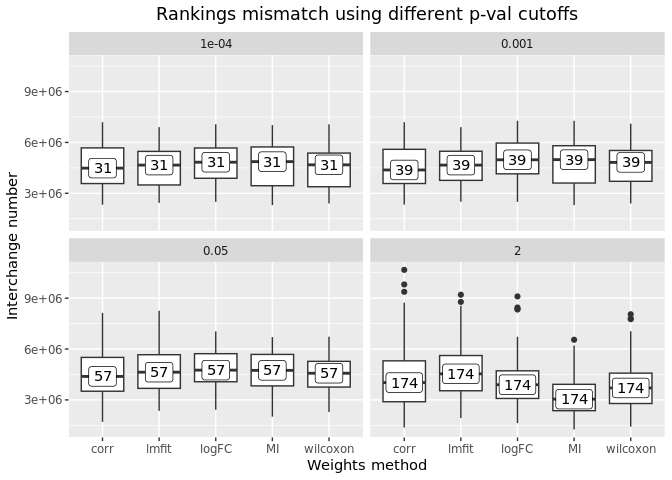

```r
accuracyComparisonPruning(input_objects$regulon, input_objects, true_ranks_matrix,
                          exp_cutoff = NULL,
                          peak_cutoff = NULL,
                          exp_assay = "norm_counts_obs",
                          peak_assay = "peak_obs") |>
    ggplot(aes(x = method, y = interchanges, label = n_tf))+
    geom_boxplot()+
    stat_summary(fun = median, geom = "label")+
    facet_wrap(~pval_cutoff, ncol = 2)+
    xlab("Weights method")+
    ylab("Interchange number")+
    ggtitle("Rankings mismatch using different p-val cutoffs")+
    theme(plot.title = element_text(hjust = 0.5))
```

### Contaminating regulon with 50% of false connections

```r
regulon.mixed <- addFalseConnections(input_objects$regulon)
```

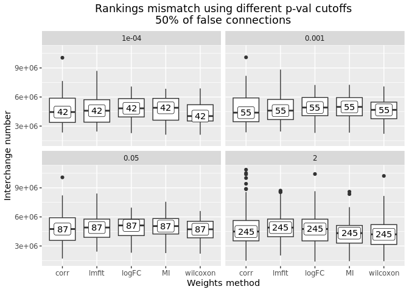

```r
accuracyComparisonPruning(regulon.mixed, input_objects, true_ranks_matrix,
                          exp_cutoff = NULL,
                          peak_cutoff = NULL,
                          exp_assay = "norm_counts_obs",
                          peak_assay = "peak_obs") |>
    ggplot(aes(x = method, y = interchanges, label = n_tf))+
    geom_boxplot()+
    stat_summary(fun = median, geom = "label")+
    facet_wrap(~pval_cutoff, ncol = 2)+
    xlab("Weights method")+
    ylab("Interchange number")+
    ggtitle("Rankings mismatch using different p-val cutoffs\n50% of false connections")+
    theme(plot.title = element_text(hjust = 0.5))
```